# Portfolio 2

Cassandra Richardson

4/30/2022

# **Cassandra Richardson’s Portfolio Piece #2 - Data Analysis Report on Boulder Safety and Stars**

# Step 1: Finding a dataset.

### An organization, Open Beta, provides open-source datasets about rock climbing on GitHub. I am using their “Boulder_Safety_and_stars” dataset, which can be found here: https://github.com/OpenBeta/climbing-data/tree/main/curated_datasets

### The description of this dataset is: “Boulder_Safety_and_Stars.csv contains the star ratings and safety grades of 24,278 boulder problems collected by Ryther Anderson using the Mountain Project API. Note that this set is not comprehensive (does not cover all states). However, it can be used to augment to existing OpenBeta database in some cases.”

### For this data analysis project, I will be exploring the relationships between how much people liked a boulder route (1-5 stars) and the rating of the route (V0-V9+)

# Step 2: Before we begin any analyses, let’s examine what this dataset includes:

```r
#View(climbing)

summary(climbing)
```

```
##        X               ID                type               name
##  Min.   :    0   Min.   :105714722   Length:24278       Length:24278
##  1st Qu.:18954   1st Qu.:107230852   Class :character   Class :character
##  Median :43625   Median :111196703   Mode  :character   Mode  :character
##  Mean   :40493   Mean   :112132220
##  3rd Qu.:59511   3rd Qu.:117568525
##  Max.   :76307   Max.   :120890927
##     Vermin              stars           votes            safety
##  Length:24278       Min.   :1.000   Min.   :  1.000   Length:24278
##  Class :character   1st Qu.:3.000   1st Qu.:  1.000   Class :character
##  Mode  :character   Median :3.700   Median :  2.000   Mode  :character
##                     Mean   :3.616   Mean   :  8.762
##                     3rd Qu.:4.000   3rd Qu.:  7.000
##                     Max.   :5.000   Max.   :612.000
```

```r
min(climbing$Vermin)
```

```
## [1] "V0"
```

```r
max(climbing$Vermin)
```

```
## [1] "V9+"
```

```r
min(climbing$stars)
```

```
## [1] 1
```

```r
max(climbing$stars)
```

```
## [1] 5
```

### The “view()” function opens the full dataset file in a new tab, so we can visually examine what the data looks like.

### The “summary()” function gives us the min, max, 1st quartile, mean, and 3rd quartile for all quantitative variables.

### I used the min() and max() functions to see the range of possible values for route rating (“Vermin”) and star rating (“stars”)

# Step 3: Let’s explore some more characteristics about the data:

```r
glimpse(climbing)
```

```
## Rows: 24,278
## Columns: 8
## $ X      <int> 0, 2, 5, 7, 9, 14, 16, 17, 18, 19, 20, 21, 22, 26, 29, 30, 31, ~
## $ ID     <int> 106464345, 108323241, 106967809, 106822513, 108673397, 10691821~
## $ type   <chr> "Boulder", "Boulder", "Boulder", "Boulder", "Boulder", "Boulder~
## $ name   <chr> "Jedi Mind Tricks", "Mutants Amok", "Baby's Head", "Heavy Traff~
## $ Vermin <chr> "V4", "V5", "V1", "V3", "V6", "V8", "V1-2", "V3-4", "V4", "V6",~
## $ stars  <dbl> 4.9, 4.7, 4.5, 4.5, 4.4, 5.0, 3.8, 3.7, 4.5, 5.0, 3.8, 4.6, 4.9~
## $ votes  <int> 146, 38, 28, 25, 25, 11, 34, 35, 20, 8, 32, 14, 8, 21, 6, 6, 14~
## $ safety <chr> "PG13", "", "R", "", "", "", "", "", "", "", "", "", "PG13", ""~
```

```r
head(climbing)
```

```
##    X        ID    type              name Vermin stars votes safety
## 1  0 106464345 Boulder  Jedi Mind Tricks     V4   4.9   146   PG13
## 2  2 108323241 Boulder      Mutants Amok     V5   4.7    38
## 3  5 106967809 Boulder       Baby's Head     V1   4.5    28      R
## 4  7 106822513 Boulder     Heavy Traffic     V3   4.5    25
## 5  9 108673397 Boulder        Le Privett     V6   4.4    25
## 6 14 106918219 Boulder She Made Me Do It     V8   5.0    11
```

```r
names(climbing)
```

```
## [1] "X"      "ID"     "type"   "name"   "Vermin" "stars"  "votes"  "safety"
```

```r
missing <- !complete.cases(climbing)
climbing[missing]
```

```
## data frame with 0 columns and 24278 rows
```

### - glimpse() shows us an overview of the whole dataset. We see that there are 24,278 rows and 8 columns, just like the help window told us.

### - head() gives us the first 6 rows of data

### - names() tells us all of the variable names: “X” “ID” “type” “name” “Vermin” “stars” “votes” “safety”

### - missing <- !complete.cases() creates an object/tibble called “missing” with any missing observations across the entire dataset

### - climbing[missing] shows us that the “missing” tibble has 0 columns. This means that there was no missing data in this dataset, which makes it easier to work with!

# Step 4: Before we begin our analyses, I want to clean this data by removing some unnnecessary rows.

### The data is already in a tidy format and has no missing values. Now, I want to analyze the correlation between route difficulty and star ratings. However, the star ratings were based on votes, and the amount of votes per route range from 1 to 612. To ensure that the star rating is more reliable, I will only be using routes that have at least 50 votes.

```r
climbing2 <- subset(climbing, votes >= 50)
```

### With the subset() function, I created a new dataset “climbing2” that only includes rows where votes were greater than or equal to 50. This brought our sample size from N = 24, 278 to N = 807.

# Step 5: Recoding the boulder rating:

### The current boulder route rating is found in the “Vermin” column and it uses the V scale. Some ratings have a range (i.e., V1-2). For those with a range, we will only use the lower number. Some ratings have a + or - score. Those will be dropped. Further, there are two ratings that are outliers as they are in the professional range, “V10-” and “V14-”; these values will be recoded to “NA”.

```r
factor(climbing2$Vermin)
```

```
##   [1] V4   V2-3 V3   V5   V4   V4   V4   V2   V4   V0   V6   V2   V3   V0   V3
##  [16] V4   V1   V3   V7-  V2   V1   V2   V3   V0-  V0+  V0   V3   V5   V0   V5
##  [31] V2   V1   V1+  V1   V1   V0-  V1   V0+  V0   V1   V0-  V2   V4   V5-  V3
##  [46] V2   V4   V6   V0-  V1   V0   V0-  V0   V0   V4+  V5-6 V1   V4   V6   V1-2
##  [61] V4   V3   V1-2 V3   V1   V6-7 V0   V5   V3-4 V0   V2   V5   V1   V1   V2-3
##  [76] V2-3 V2   V0   V1+  V2-3 V6   V3   V1   V7   V1   V4   V4   V6   V2-  V0
##  [91] V3   V1   V5   V7   V5   V4-  V4   V4   V2   V6   V5   V1+  V6   V5   V1
## [106] V6   V3   V4   V6   V6   V1   V4   V0   V5   V4   V5   V0   V0+  V4   V3
## [121] V6   V6   V6   V4   V6   V4   V0-  V4   V7   V3   V1   V1+  V3   V5   V3
## [136] V3   V4   V4   V2+  V5   V5   V0+  V0+  V5   V4   V1   V3   V2   V0+  V3
## [151] V7   V8   V4   V5   V5   V4   V0+  V0   V6   V2   V1+  V1   V2   V2   V0+
## [166] V2-3 V1   V1   V5   V0-  V3   V3-  V3   V0-  V1   V0+  V1   V5   V3   V4
## [181] V2   V3   V8   V1   V3   V0-  V4   V4   V7-  V4   V4   V5   V3+  V0-  V1
## [196] V1   V2   V4   V2   V3   V5-6 V3   V2-  V4   V1   V3   V5-  V3-  V4   V5
## [211] V4   V3   V3   V3   V5   V2   V2   V1   V2   V1   V3   V3+  V0+  V3   V2
```

[output cut: 40 more lines]

```r
climbing_recoded <- climbing2 |>
  mutate(
    Vermin = recode(Vermin, "V0-" = "V0", "V0+" = "V0", "V0-1" = "V0", "V1-" = "V1", "V1+" = "V1", "V1-2" = "V1", "V2-" = "V2", "V2+" = "V2", "V2-3" = "V2", "V3-" = "V3", "V3+" = "V3", "V3-4" = "V3", "V4-" = "V4", "V4+" = "V4", "V4-5" = "V4", "V5-" = "V5", "V5-6" = "V5", "V5+" = "V5", "V6-"= "V6", "V6-7" = "V6", "V6+" = "V6", "V7-" = "V7", "V7+" = "V7", "V8-" = "V8", "V9-" = "V9", "V10-" = "NA", "V14-" = "NA"
  ))

factor(climbing_recoded$Vermin)
```

```
##   [1] V4 V2 V3 V5 V4 V4 V4 V2 V4 V0 V6 V2 V3 V0 V3 V4 V1 V3 V7 V2 V1 V2 V3 V0 V0
##  [26] V0 V3 V5 V0 V5 V2 V1 V1 V1 V1 V0 V1 V0 V0 V1 V0 V2 V4 V5 V3 V2 V4 V6 V0 V1
##  [51] V0 V0 V0 V0 V4 V5 V1 V4 V6 V1 V4 V3 V1 V3 V1 V6 V0 V5 V3 V0 V2 V5 V1 V1 V2
##  [76] V2 V2 V0 V1 V2 V6 V3 V1 V7 V1 V4 V4 V6 V2 V0 V3 V1 V5 V7 V5 V4 V4 V4 V2 V6
## [101] V5 V1 V6 V5 V1 V6 V3 V4 V6 V6 V1 V4 V0 V5 V4 V5 V0 V0 V4 V3 V6 V6 V6 V4 V6
## [126] V4 V0 V4 V7 V3 V1 V1 V3 V5 V3 V3 V4 V4 V2 V5 V5 V0 V0 V5 V4 V1 V3 V2 V0 V3
## [151] V7 V8 V4 V5 V5 V4 V0 V0 V6 V2 V1 V1 V2 V2 V0 V2 V1 V1 V5 V0 V3 V3 V3 V0 V1
## [176] V0 V1 V5 V3 V4 V2 V3 V8 V1 V3 V0 V4 V4 V7 V4 V4 V5 V3 V0 V1 V1 V2 V4 V2 V3
## [201] V5 V3 V2 V4 V1 V3 V5 V3 V4 V5 V4 V3 V3 V3 V5 V2 V2 V1 V2 V1 V3 V3 V0 V3 V2
## [226] V5 V3 V1 V0 V6 V4 V6 V5 V3 V2 V6 V7 V5 V5 V4 V7 V1 V6 V3 V5 V6 V0 V4 V2 V5
## [251] V3 V4 V4 V3 V4 V3 V2 V3 V7 V3 V5 V7 V3 V4 V7 V7 V3 V4 V3 V8 V2 V1 V6 V2 V4
## [276] V5 V3 V2 V1 V2 V3 V7 V9 V3 V4 V3 V5 V5 V2 V7 V5 V1 V5 V4 V3 V4 V4 V1 V1 V2
## [301] V2 V2 V3 V3 V1 V3 V2 V1 V0 V2 V1 V4 V2 V2 V0 V7 V5 V7 V6 V4 V3 V3 V3 V4 V3
## [326] V3 V1 V5 V2 V5 V6 V1 NA V2 V1 V7 V7 V2 V4 V2 V6 V6 V3 V5 V4 V5 V1 V0 V5 V4
## [351] V5 V2 V2 V4 V2 V3 V1 V3 V3 V2 V2 V0 V1 V1 V6 V6 V4 V8 V5 V4 V7 V6 V9 V5 V3
```

[output cut: 19 more lines]

# Step 6: Find the mean star rating for each boulder rating.

```r
climbing_stars <- climbing_recoded |>
  group_by(Vermin)|>
  summarize(
    mean = mean(stars),
    sd = sd(stars),
    min = min(stars),
    max = max(stars)
  )

print(climbing_stars)
```

```
## # A tibble: 11 x 5
##    Vermin  mean     sd   min   max
##    <chr>  <dbl>  <dbl> <dbl> <dbl>
##  1 NA      4.75 0.0707   4.7   4.8
##  2 V0      3.52 0.525    2.4   4.8
##  3 V1      3.55 0.508    2.6   5
##  4 V2      3.80 0.495    2.7   4.9
##  5 V3      3.97 0.433    3     4.9
##  6 V4      4.21 0.458    3     5
##  7 V5      4.15 0.474    2.8   5
##  8 V6      4.32 0.417    3.1   4.9
##  9 V7      4.33 0.389    3.4   5
## 10 V8      4.54 0.431    3.6   5
## 11 V9      4.85 0.212    4.7   5
```

# Step 7: Let’s visualize our data using a bar graph.

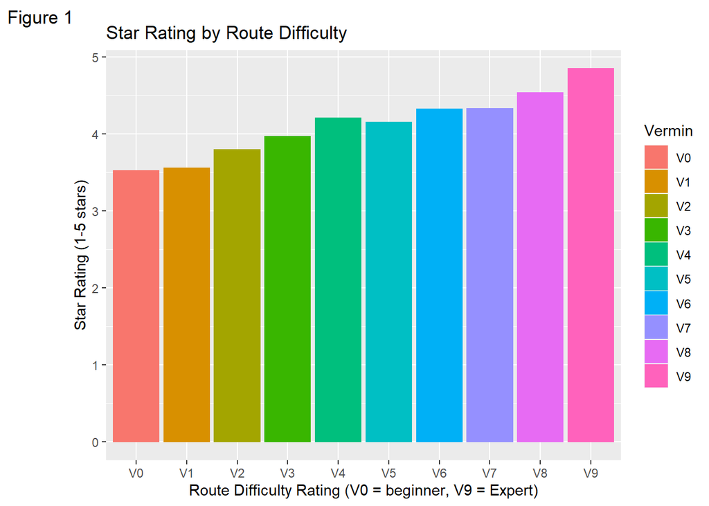

```r
climbing_recoded |>
  filter(climbing_recoded$Vermin != "NA") |>
ggplot(mapping = aes(x = Vermin, y = stars, color = Vermin, fill = Vermin)) +
  geom_bar(stat = "summary", fun = "mean") +
  labs(
    title = "Star Rating by Route Difficulty",
    tag = "Figure 1",
    x = "Route Difficulty Rating (V0 = beginner, V9 = Expert)",
    y = "Star Rating (1-5 stars)")
```

# Step 8: Now let’s visualize our data using a scatterplot.

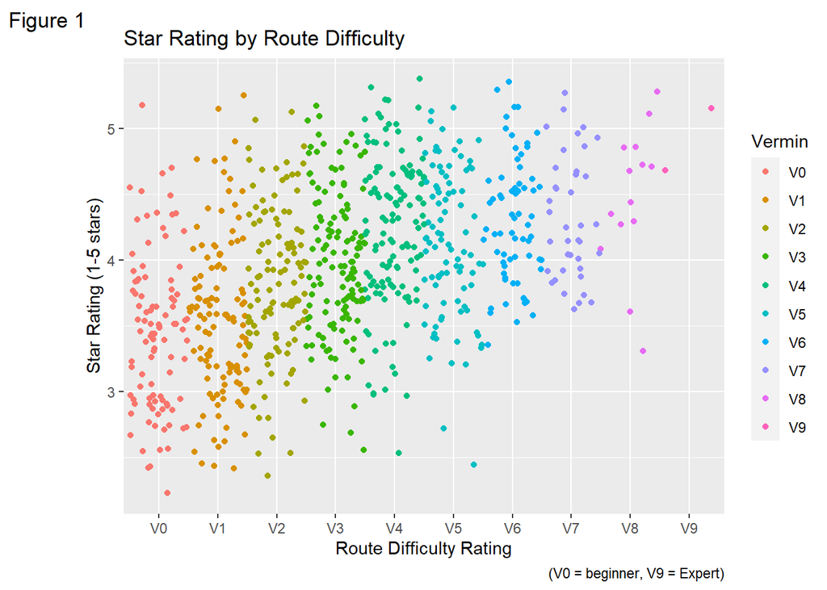

```r
climbing_recoded |>
  filter(climbing_recoded$Vermin != "NA") |>
ggplot(mapping = aes(x = Vermin, y = stars, color = Vermin)) +
  geom_jitter(height = .5, width = .5) +
  labs(
    title = "Star Rating by Route Difficulty",
    tag = "Figure 1",
    x = "Route Difficulty Rating",
    caption = "(V0 = beginner, V9 = Expert)",
    y = "Star Rating (1-5 stars)")
```

# Step 9: Let’s perform the Chi-square test of independence to see if there is a relationship between star rating and route difficulty:

```r
chi_square <- chisq.test(climbing_recoded$stars, climbing_recoded$Vermin)
chi_square
```

```
##
##  Pearson's Chi-squared test
##
## data:  climbing_recoded$stars and climbing_recoded$Vermin
## X-squared = 538.41, df = 250, p-value < 2.2e-16
```

### Our Chi-square test was signficant at *p* < .001! *X^2* = 538.41. I would interpret this to mean that there is a correlation between star rating and route difficulty, such that higher levels of difficulty are associated with higher star ratings.

#### *Note for Dr. Wiernik: For this correlation test, I chose to use the Chi-square test because route difficulty (“Vermin”) is a categorical variable. Although I am not sure if this is the correct test, I wanted to gain practice in running correlations in R.*

# Step 10: Let’s conduct a one-way Analysis of Variance (ANOVA) test to see if the is a statistically significant difference in the average star rating between the different difficulties of routes.

```r
anova <- aov(stars ~ Vermin, data = climbing_recoded)

anova_output <- summary(anova)

print(anova_output)
```

```
##              Df Sum Sq Mean Sq F value Pr(>F)
## Vermin       10  74.48   7.448   33.64 <2e-16 ***
## Residuals   796 176.23   0.221
## ---
## Signif. codes:  0 '***' 0.001 '**' 0.01 '*' 0.05 '.' 0.1 ' ' 1
```

### I conducted a one-way ANOVA with route difficultly (NA, V0, V1, V2, V3, V4, V5, V6, V7, V8, V9) as the between-subjects factor. There was sufficient evidence to conclude that route difficulty had an effect on the star rating of the route, *F* (10, 796) = 33.64, *p* < .001.

#### *Note for Dr. Wiernik: The dataset does not clarify how the scores were measured, so I am not sure if this is between-subjects or within-subjects. For the sake of practice, I chose to interpret the data as between-subjects.*

# Step 11: Since there are more than two levels of the IV (route difficulty), we need to run post-hoc tests to see which diets are significantly different from each other.

```r
TukeyHSD(anova)
```

```
##   Tukey multiple comparisons of means
##     95% family-wise confidence level
##
## Fit: aov(formula = stars ~ Vermin, data = climbing_recoded)
##
## $Vermin
##               diff         lwr        upr     p adj
## V0-NA -1.229591837 -2.31450995 -0.1446737 0.0120998
## V1-NA -1.195833333 -2.27876061 -0.1129061 0.0168212
## V2-NA -0.954310345 -2.03754366  0.1289230 0.1436260
## V3-NA -0.781297710 -1.86347938  0.3008840 0.4138844
## V4-NA -0.542857143 -1.62536165  0.5396474 0.8741659
## V5-NA -0.600549451 -1.68630180  0.4852029 0.7886301
## V6-NA -0.426470588 -1.51616460  0.6632234 0.9745116
## V7-NA -0.419230769 -1.52043945  0.6819779 0.9791204
## V8-NA -0.214285714 -1.36245513  0.9338837 0.9999510
## V9-NA  0.100000000 -1.41888536  1.6188854 1.0000000
## V1-V0  0.033758503 -0.17304104  0.2405581 0.9999861
## V2-V0  0.275281492  0.06688526  0.4836777 0.0011307
## V3-V0  0.448294127  0.24543523  0.6511530 0.0000000
## V4-V0  0.686734694  0.48216057  0.8913088 0.0000000
## V5-V0  0.629042386  0.40792537  0.8501594 0.0000000
## V6-V0  0.803121248  0.56339723  1.0428453 0.0000000
## V7-V0  0.810361068  0.52279348  1.0979287 0.0000000
## V8-V0  1.015306122  0.58133888  1.4492734 0.0000000
## V9-V0  1.329591837  0.24467372  2.4145100 0.0039757
## V2-V1  0.241522989  0.04375255  0.4392934 0.0041967
## V3-V1  0.414535623  0.22260884  0.6064624 0.0000000
## V4-V1  0.652976190  0.45923737  0.8467150 0.0000000
## V5-V1  0.595283883  0.38415147  0.8064163 0.0000000
## V6-V1  0.769362745  0.53881608  0.9999094 0.0000000
## V7-V1  0.776602564  0.49663957  1.0565656 0.0000000
## V8-V1  0.981547619  0.55258173  1.4105135 0.0000000
## V9-V1  1.295833333  0.21290606  2.3787606 0.0056999
## V3-V2  0.173012635 -0.02063350  0.3666588 0.1298973
## V4-V2  0.411453202  0.21601097  0.6068954 0.0000000
## V5-V2  0.353760894  0.14106433  0.5664575 0.0000056
## V6-V2  0.527839757  0.29585980  0.7598197 0.0000000
## V7-V2  0.535079576  0.25393510  0.8162240 0.0000001
## V8-V2  0.740024631  0.31028673  1.1697625 0.0000020
## V9-V2  1.054310345 -0.02892297  2.1375437 0.0645165
## V4-V3  0.238440567  0.04891376  0.4279674 0.0026192
## V5-V3  0.180748259 -0.02652589  0.3880224 0.1541480
## V6-V3  0.354827122  0.12780853  0.5818457 0.0000300
## V7-V3  0.362066941  0.08500204  0.6391318 0.0013715
## V8-V3  0.567011996  0.13993190  0.9940921 0.0010313
## V9-V3  0.881297710 -0.20088396  1.9634794 0.2355801
## V5-V4 -0.057692308 -0.26664544  0.1512608 0.9983742
## V6-V4  0.116386555 -0.11216603  0.3449391 0.8628905
## V7-V4  0.123626374 -0.15469682  0.4019496 0.9396596
## V8-V4  0.328571429 -0.09932605  0.7564689 0.3186036
## V9-V4  0.642857143 -0.43964736  1.7253616 0.7060272
## V6-V5  0.174078862 -0.06939279  0.4175505 0.4292910
## V7-V5  0.181318681 -0.10938041  0.4720178 0.6395864
## V8-V5  0.386263736 -0.04978490  0.8223124 0.1381661
## V9-V5  0.700549451 -0.38520290  1.7863018 0.5900259
## V7-V6  0.007239819 -0.29785169  0.3123313 1.0000000
## V8-V6  0.212184874 -0.23358781  0.6579576 0.9071622
## V9-V6  0.526470588 -0.56322342  1.6161646 0.8985491
## V8-V7  0.204945055 -0.26827878  0.6781689 0.9488396
## V9-V7  0.519230769 -0.58197791  1.6204394 0.9123182
## V9-V8  0.314285714 -0.83388370  1.4624551 0.9984894
```

# **Interpretation of the Findings**

### Based on our analyses, there is a signficant relationship between boulder route difficulty and star rating such that more difficult routes have higher star ratings. This relationship is especially prevalent among the beginner-intermediate routes (V0, V1, V2, and V3), with less differences in star ratings at the most difficult levels of routes.

### Unfortunately, information about the data is limited, preventing the ability to make clearer interpretations.Primarily, the method of data collection and information about the measures was vague. I am assuming that star rating reflects how much people enjoyed the route for the sake of analyses.

### If my understanding of the data is correct, then we can infer that people tend to enjoy more difficult routes. Future studies can examine if this relationship still exists when controlling for skill level (i.e., do people still enjoy advanced routes if they are a beginner?). Future studies can also examine what aspects of the route people enjoyed (i.e., location, rock type, hold type, etc.) to aid in developing more enjoyable indoor climbing routes.